# Wilcoxon rank-sum test

Independent 2 samples

## Wilcoxon rank-sum test

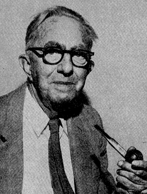

Developed by [Frank Wilcoxon](http://en.wikipedia.org/wiki/Frank_Wilcoxon) the rank-sum test is a [nonparametric](http://en.wikipedia.org/wiki/Nonparametric_statistics) alternative to the independent samples t-test.

By first ranking $x$ and then sum these ranks per group one would expect, under the null hypothesis, equal values for both groups.

After standardising this difference one can test using a standard normal distribution.

## Simulate data

```r
n      = 20
factor = rep(c("Ecstasy","Alcohol"),each=n/2)
dummy  = ifelse(factor == "Ecstacy", 0, 1)
b.0    = 23
b.1    = 5
error  = rnorm(n, 0, 1.7)
depres = b.0 + b.1*dummy + error
depres = round(depres)

data <- data.frame(factor, depres)

## add the ranks
data$R <- rank(data$depres)
```

## Example

|  | factor | depres | R |
| --- | --- | --- | --- |
| 1 | Ecstasy | 28 | 11.5 |
| 2 | Ecstasy | 30 | 18 |
| 3 | Ecstasy | 28 | 11.5 |
| 4 | Ecstasy | 27 | 7 |
| 5 | Ecstasy | 29 | 15.5 |
| 6 | Ecstasy | 28 | 11.5 |
| 7 | Ecstasy | 26 | 4.5 |
| 8 | Ecstasy | 26 | 4.5 |
| 9 | Ecstasy | 27 | 7 |
| 10 | Ecstasy | 27 | 7 |

[output cut: 10 more lines]

## Calculate the sum of ranks per group

```r
R <- aggregate(R ~ factor, data, sum)
R
```

```
##    factor   R
## 1 Alcohol 112
## 2 Ecstasy  98
```

## So W is the lowest

$W=min\left(\sum{R_1},\sum{R_2}\right)$

`r W <- min(R$R) W`

`## [1] 98`

## Standardise W

To calculate the Z score we need to standardise the W. To do so we need the mean W and the standard error of W.

For this we need the sample sizes for each group.

```r
n <- aggregate(R ~ factor, data, length)

n.1 = n$R[1]
n.2 = n$R[2]

cbind(n.1, n.2)
```

```
##      n.1 n.2
## [1,]  10  10
```

## Mean W

$\bar{W}_s=\frac{n_1(n_1+n_2+1)}{2}$

`r W.mean = (n.1*(n.1+n.2+1))/2 W.mean`

`## [1] 105`

## SE W

${SE}_{\bar{W}_s}=\sqrt{ \frac{n_1 n_2 (n_1+n_2+1)}{12} }$

`r W.se = sqrt((n.1*n.2*(n.1+n.2+1))/12) W.se`

`## [1] 13.22876`

## Calculate Z

$z = \frac{W - \bar{W}}{{SE}_W}$

Which looks a lot like

$\frac{X - \bar{X}}{{SE}_X} \text{or} \frac{b - \mu_{b}}{{SE}_b}$

`r z = (W - W.mean) / W.se z`

`## [1] -0.5291503`

## Test for significance

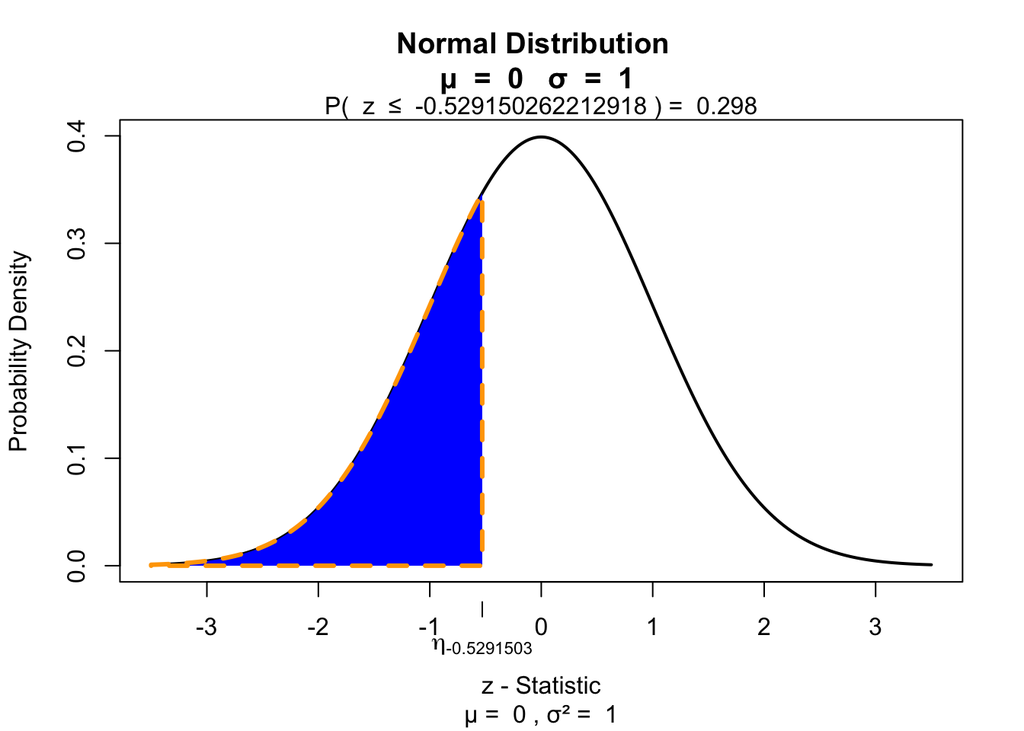

## Test for significance

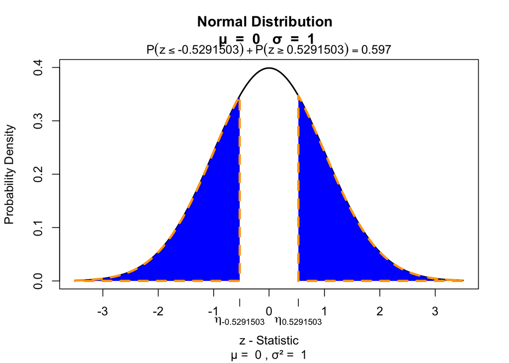

## Effect size

$r = \frac{z}{\sqrt{N}}$

`r N = sum(n$R) r = z / sqrt(N) r`

`## [1] -0.1183216`

## Mann–Whitney test

$U = n_1 n_2 + \frac{n_1 (n_1 + 1)}{2} - R_1$

`r U = (n.1*n.2)+(n.1*(n.1+1))/2-R$R[1] U`

`## [1] 43`

## $\bar{U}$ and ${SE}_U$ for non tied ranks

$\bar{U} = \frac{n_1 n_2}{2}$

`r (n.1*n.2)/2`

`## [1] 50`

${SE}_U = \sqrt{\frac{n_1 n_2 (n_1 + n_2 + 1)}{12}}$

`r sqrt((n.1*n.2*(n.1+n.2+1))/12)`

`## [1] 13.22876`